# Analyse exploratoire du jeu de données TP5_a25_reg_app

Engel CALON, Bastien CUVILLIER, Camille MILON

### TP5_a25_reg_app

Jeu de données dédié à la régression

#### Chargement des données

```r
if(!require(here)) install.packages("here")
library(here)
library(magrittr)
library(tidyverse)
# Chemin vers les données

data_path <- here("src", "data", "TP5_a25_reg_app.txt")

# Lecture des données
reg_data <- read.table(
  data_path,
  header = TRUE,
  sep = " ",
  quote = "\"",
  stringsAsFactors = FALSE
)

# y as factor ?

# Aperçu
head(reg_data)
```

|  | X1 | X2 | X3 | X4 | X5 | X6 | X7 | X8 | X9 | X10 | X11 | X12 | X13 | X14 | X15 | X16 | X17 | X18 | X19 | X20 | X21 | X22 | X23 | X24 | X25 | X26 | X27 | X28 | X29 | … |
| --- | --- | --- | --- | --- | --- | --- | --- | --- | --- | --- | --- | --- | --- | --- | --- | --- | --- | --- | --- | --- | --- | --- | --- | --- | --- | --- | --- | --- | --- | --- |
| 1 | 2.752167 | 9.8805752 | 1.1663056 | 5.2398746 | 3.754376 | 1.752407 | 8.305465 | 3.987163 | 4.5949229 | 9.386949 | 3.914966 | 4.709920 | 4.3829353 | 8.0804646 | 9.866756 | 8.370788 | 9.078772 | 2.419837 | 3.014325 | 0.06793073 | 1.6443629 | 9.4804693 | 7.612598 | 5.8769416 | 8.2445310 | 2.079186 | 0.888948 | 5.1300534 | 4.1283824 | … |
| 2 | 1.073551 | 7.7489832 | 0.7194965 | 4.5247237 | 4.719189 | 2.010465 | 1.621430 | 5.295231 | 0.8223045 | 8.785385 | 3.843211 | 4.899518 | 0.4180606 | 4.8265399 | 8.552448 | 9.760444 | 8.081750 | 5.572566 | 7.482596 | 0.60811651 | 6.5126915 | 2.0546667 | 9.094140 | 9.5739537 | 3.4737355 | 1.709870 | 7.283480 | 0.6961470 | 0.3446929 | … |
| 3 | 4.148441 | 3.6709274 | 0.6795029 | 2.8300751 | 9.728511 | 4.547372 | 2.291726 | 7.084398 | 6.9771495 | 2.481368 | 5.010757 | 1.679289 | 7.8045554 | 9.5903419 | 8.927292 | 5.210123 | 1.599757 | 1.351901 | 3.814977 | 7.06755799 | 0.1705733 | 5.3669361 | 2.215141 | 3.0446082 | 6.2391700 | 3.213079 | 1.757410 | 5.1903942 | 1.5297035 | … |
| 4 | 5.687933 | 9.2918162 | 3.7965405 | 0.9216322 | 3.724015 | 3.914180 | 1.130888 | 7.331793 | 8.6914261 | 1.213638 | 7.561360 | 5.404303 | 1.0315051 | 4.0356641 | 2.316361 | 5.182127 | 1.751789 | 2.057549 | 2.618388 | 0.63795006 | 0.4865197 | 0.5420127 | 7.707674 | 0.8411077 | 5.8387574 | 7.586306 | 6.078537 | 8.7517965 | 3.0119834 | … |
| 5 | 7.510912 | 0.4742735 | 7.3253352 | 2.8652192 | 7.938086 | 8.415629 | 4.405845 | 5.150942 | 5.2236815 | 1.831186 | 7.148366 | 1.259206 | 4.9853544 | 0.5654166 | 2.976573 | 9.548106 | 4.237128 | 8.373154 | 3.049219 | 7.16551677 | 1.5814709 | 9.8589777 | 8.101328 | 1.7527947 | 0.5542473 | 7.495355 | 4.651795 | 0.9905147 | 7.8229538 | … |
| 6 | 4.049770 | 0.5540013 | 2.8414876 | 0.5182126 | 8.521179 | 0.791488 | 0.521261 | 9.049682 | 8.8166657 | 7.628056 | 1.933798 | 4.632209 | 9.0749587 | 2.9793489 | 9.245866 | 6.288173 | 7.383008 | 8.544974 | 1.631202 | 5.40267240 | 9.3716552 | 0.6312747 | 6.756852 | 2.6664629 | 6.6124463 | 6.501771 | 7.322921 | 0.6281063 | 1.6165735 | … |

```r
dim(reg_data)
```

```
[1] 500 101
```

```r
str(reg_data)
```

```
'data.frame':   500 obs. of  101 variables:
 $ X1  : num  2.75 1.07 4.15 5.69 7.51 ...
 $ X2  : num  9.881 7.749 3.671 9.292 0.474 ...
 $ X3  : num  1.166 0.719 0.68 3.797 7.325 ...
 $ X4  : num  5.24 4.525 2.83 0.922 2.865 ...
 $ X5  : num  3.75 4.72 9.73 3.72 7.94 ...
 $ X6  : num  1.75 2.01 4.55 3.91 8.42 ...
 $ X7  : num  8.31 1.62 2.29 1.13 4.41 ...
 $ X8  : num  3.99 5.3 7.08 7.33 5.15 ...
 $ X9  : num  4.595 0.822 6.977 8.691 5.224 ...
 $ X10 : num  9.39 8.79 2.48 1.21 1.83 ...
 $ X11 : num  3.91 3.84 5.01 7.56 7.15 ...
 $ X12 : num  4.71 4.9 1.68 5.4 1.26 ...
 $ X13 : num  4.383 0.418 7.805 1.032 4.985 ...
 $ X14 : num  8.08 4.827 9.59 4.036 0.565 ...
```

[output cut: 86 more lines]

Le jeu de données est composé de **500 observations**, de **100 variables numériques** (X1 à X100) et d’une **variable cible numérique** y.

#### Résumé statistique

```r
# Résumé statistique simple
summary(reg_data)
```

```
       X1               X2                  X3               X4                X5                X6                X7
 Min.   :0.0176   Min.   :0.0006267   Min.   :0.1008   Min.   :0.03388   Min.   :0.01003   Min.   :0.02705   Min.   :0.01791
 1st Qu.:2.3818   1st Qu.:2.4679715   1st Qu.:2.5132   1st Qu.:2.59619   1st Qu.:2.62652   1st Qu.:2.62134   1st Qu.:2.27581
 Median :4.9050   Median :4.8562108   Median :4.7167   Median :4.96407   Median :5.18397   Median :4.85946   Median :4.80908
 Mean   :4.9350   Mean   :4.9964429   Mean   :4.8330   Mean   :4.98905   Mean   :5.10339   Mean   :4.97065   Mean   :4.87404
 3rd Qu.:7.4366   3rd Qu.:7.6950409   3rd Qu.:7.3339   3rd Qu.:7.47705   3rd Qu.:7.50455   3rd Qu.:7.55246   3rd Qu.:7.36047
 Max.   :9.9785   Max.   :9.9786456   Max.   :9.9994   Max.   :9.96549   Max.   :9.98367   Max.   :9.97473   Max.   :9.99397
       X8                  X9                X10                X11               X12               X13
 Min.   :0.0000997   Min.   :0.002718   Min.   :0.006632   Min.   :0.02041   Min.   :0.03706   Min.   :0.001254
 1st Qu.:2.4322284   1st Qu.:2.773364   1st Qu.:2.330596   1st Qu.:2.42732   1st Qu.:2.47243   1st Qu.:2.441169
 Median :5.1244725   Median :5.197434   Median :4.895472   Median :5.01908   Median :4.95274   Median :4.896046
 Mean   :4.9713598   Mean   :5.175003   Mean   :4.961824   Mean   :4.96085   Mean   :4.97053   Mean   :4.884611
 3rd Qu.:7.4576397   3rd Qu.:7.692273   3rd Qu.:7.517748   3rd Qu.:7.54361   3rd Qu.:7.44612   3rd Qu.:7.410181
 Max.   :9.9810319   Max.   :9.985074   Max.   :9.998493   Max.   :9.96863   Max.   :9.98150   Max.   :9.998195
      X14               X15               X16               X17               X18                X19               X20
 Min.   :0.05004   Min.   :0.03387   Min.   :0.01471   Min.   :0.07576   Min.   :0.007481   Min.   :0.01568   Min.   :0.0137
 1st Qu.:2.75126   1st Qu.:2.55178   1st Qu.:2.54520   1st Qu.:2.21034   1st Qu.:2.525868   1st Qu.:2.66998   1st Qu.:2.2965
 Median :5.13046   Median :5.46926   Median :5.11190   Median :4.89982   Median :4.809602   Median :5.32687   Median :4.9320
 Mean   :5.11912   Mean   :5.25393   Mean   :5.07527   Mean   :4.93675   Mean   :4.916288   Mean   :5.15577   Mean   :4.8341
 3rd Qu.:7.67218   3rd Qu.:7.97789   3rd Qu.:7.65953   3rd Qu.:7.64644   3rd Qu.:7.239508   3rd Qu.:7.68475   3rd Qu.:7.0705
 Max.   :9.99376   Max.   :9.97760   Max.   :9.96564   Max.   :9.99718   Max.   :9.996160   Max.   :9.98171   Max.   :9.9356
      X21               X22                X23               X24                X25               X26
 Min.   :0.05015   Min.   :0.003372   Min.   :0.02916   Min.   :0.005548   Min.   :0.05095   Min.   :0.02101
 1st Qu.:2.36568   1st Qu.:2.439631   1st Qu.:2.38733   1st Qu.:2.426654   1st Qu.:2.66277   1st Qu.:2.73117
 Median :4.87920   Median :5.097529   Median :5.08576   Median :4.638501   Median :5.08995   Median :5.47529
 Mean   :4.91839   Mean   :4.842944   Mean   :5.03649   Mean   :4.804623   Mean   :5.02919   Mean   :5.24790
 3rd Qu.:7.62894   3rd Qu.:6.966691   3rd Qu.:7.61503   3rd Qu.:7.280197   3rd Qu.:7.42252   3rd Qu.:7.88578
 Max.   :9.98321   Max.   :9.952251   Max.   :9.91419   Max.   :9.987637   Max.   :9.99656   Max.   :9.99725
      X27                X28                X29                X30                X31                X32
 Min.   :0.006975   Min.   :0.005259   Min.   :0.004523   Min.   :0.001612   Min.   :0.009166   Min.   :0.00104
 1st Qu.:2.628137   1st Qu.:2.660656   1st Qu.:2.301896   1st Qu.:2.319334   1st Qu.:2.418254   1st Qu.:2.42962
 Median :5.156860   Median :4.921117   Median :4.914084   Median :4.709464   Median :4.935532   Median :4.68432
 Mean   :5.002726   Mean   :5.065631   Mean   :4.885600   Mean   :4.788505   Mean   :4.968431   Mean   :4.83089
 3rd Qu.:7.282507   3rd Qu.:7.591224   3rd Qu.:7.285889   3rd Qu.:7.053205   3rd Qu.:7.656323   3rd Qu.:7.12755
 Max.   :9.975920   Max.   :9.990780   Max.   :9.996658   Max.   :9.989881   Max.   :9.997150   Max.   :9.97726
      X33               X34                 X35               X36               X37               X38
 Min.   :0.00226   Min.   :0.0005745   Min.   :0.04184   Min.   :0.01453   Min.   :0.02925   Min.   :0.003316
 1st Qu.:2.36268   1st Qu.:2.7081972   1st Qu.:2.81971   1st Qu.:2.59042   1st Qu.:2.32353   1st Qu.:2.539169
 Median :5.00471   Median :5.0965487   Median :5.31440   Median :5.47833   Median :5.09403   Median :4.911193
 Mean   :5.03693   Mean   :5.1376289   Mean   :5.15282   Mean   :5.24540   Mean   :5.01861   Mean   :4.955249
```

[output cut: 57 more lines]

```
 Max.   :9.99547   Max.   :9.957971   Max.   :9.95964   Max.   :9.977759   Max.   :9.96560   Max.   :9.98022   Max.   :9.99071
      X92               X93               X94               X95               X96               X97               X98
 Min.   :0.01346   Min.   :0.01385   Min.   :0.02104   Min.   :0.05837   Min.   :0.00893   Min.   :0.05206   Min.   :0.003778
 1st Qu.:2.39858   1st Qu.:2.48257   1st Qu.:2.41276   1st Qu.:2.27180   1st Qu.:2.54934   1st Qu.:2.36198   1st Qu.:2.255927
 Median :4.92354   Median :5.00065   Median :5.26023   Median :4.64394   Median :5.06100   Median :4.54794   Median :4.942796
 Mean   :4.94479   Mean   :4.92010   Mean   :4.99017   Mean   :4.75337   Mean   :4.98193   Mean   :4.86726   Mean   :4.851866
 3rd Qu.:7.45429   3rd Qu.:7.29649   3rd Qu.:7.51894   3rd Qu.:7.18590   3rd Qu.:7.38390   3rd Qu.:7.26440   3rd Qu.:7.357370
 Max.   :9.99304   Max.   :9.99823   Max.   :9.96550   Max.   :9.99152   Max.   :9.99421   Max.   :9.99391   Max.   :9.993956
      X99               X100               y
 Min.   :0.04611   Min.   :0.00265   Min.   :-168.99
 1st Qu.:2.51539   1st Qu.:2.66604   1st Qu.: -26.78
 Median :4.96597   Median :5.02804   Median :  17.46
 Mean   :4.94024   Mean   :5.07614   Mean   :  17.69
 3rd Qu.:7.29469   3rd Qu.:7.59122   3rd Qu.:  58.09
 Max.   :9.99724   Max.   :9.99512   Max.   : 182.04
```

##### Variables descriptives

- Les X semblent **toutes bornées entre environ 0 et 10**, probablement issues d’une génération aléatoire uniforme ou d’une normalisation.
- Les moyennes et médianes des X sont très proches (autour de 5) => **symétrie globale** des distributions, pas de fort déséquilibre entre les variables
- Les plages suggèrent que toutes les variables ont la **même échelle** => pas besoin de normalisation (ce qui est étrange pour de la regression…)
- Les écarts entre les quartiles sont constants => **dispersion moyenne constante** entre les variables

##### Variable cible

- La variable cible y est continue et non bornée, avec une **plage de [-169, 182]** => y varie fortement
- La moyenne et la médiane sont proches => **pas d’asymétrie**
- Valeurs aberrantes possibles (à vérifier par la suite)

```r
# Statistiques détaillées
library(psych)
psych::describe(reg_data)
```

|  | vars | n | mean | sd | median | trimmed | mad | min | max | range | skew | kurtosis | se |
| --- | --- | --- | --- | --- | --- | --- | --- | --- | --- | --- | --- | --- | --- |
| X1 | 1 | 500 | 4.93 | 2.89 | 4.90 | 4.93 | 3.74 | 0.02 | 9.98 | 9.96 | -0.01 | -1.24 | 0.13 |
| X2 | 2 | 500 | 5.00 | 2.89 | 4.86 | 5.00 | 3.82 | 0.00 | 9.98 | 9.98 | 0.03 | -1.22 | 0.13 |
| X3 | 3 | 500 | 4.83 | 2.81 | 4.72 | 4.81 | 3.47 | 0.10 | 10.00 | 9.90 | 0.07 | -1.16 | 0.13 |
| X4 | 4 | 500 | 4.99 | 2.87 | 4.96 | 4.99 | 3.64 | 0.03 | 9.97 | 9.93 | 0.01 | -1.19 | 0.13 |
| X5 | 5 | 500 | 5.10 | 2.87 | 5.18 | 5.12 | 3.64 | 0.01 | 9.98 | 9.97 | -0.06 | -1.21 | 0.13 |
| X6 | 6 | 500 | 4.97 | 2.86 | 4.86 | 4.98 | 3.60 | 0.03 | 9.97 | 9.95 | 0.02 | -1.16 | 0.13 |
| X7 | 7 | 500 | 4.87 | 2.93 | 4.81 | 4.83 | 3.77 | 0.02 | 9.99 | 9.98 | 0.08 | -1.22 | 0.13 |
| X8 | 8 | 500 | 4.97 | 2.97 | 5.12 | 4.97 | 3.75 | 0.00 | 9.98 | 9.98 | -0.01 | -1.23 | 0.13 |
| X9 | 9 | 500 | 5.18 | 2.85 | 5.20 | 5.22 | 3.63 | 0.00 | 9.99 | 9.98 | -0.10 | -1.19 | 0.13 |
| X10 | 10 | 500 | 4.96 | 2.93 | 4.90 | 4.95 | 3.88 | 0.01 | 10.00 | 9.99 | 0.01 | -1.25 | 0.13 |

[output cut: 91 more lines]

```r
# Vérification des valeurs manquantes
colSums(is.na(reg_data))
```

```
  X1   X2   X3   X4   X5   X6   X7   X8   X9  X10  X11  X12  X13  X14  X15  X16  X17  X18  X19  X20  X21  X22  X23  X24  X25
   0    0    0    0    0    0    0    0    0    0    0    0    0    0    0    0    0    0    0    0    0    0    0    0    0
 X26  X27  X28  X29  X30  X31  X32  X33  X34  X35  X36  X37  X38  X39  X40  X41  X42  X43  X44  X45  X46  X47  X48  X49  X50
   0    0    0    0    0    0    0    0    0    0    0    0    0    0    0    0    0    0    0    0    0    0    0    0    0
 X51  X52  X53  X54  X55  X56  X57  X58  X59  X60  X61  X62  X63  X64  X65  X66  X67  X68  X69  X70  X71  X72  X73  X74  X75
   0    0    0    0    0    0    0    0    0    0    0    0    0    0    0    0    0    0    0    0    0    0    0    0    0
 X76  X77  X78  X79  X80  X81  X82  X83  X84  X85  X86  X87  X88  X89  X90  X91  X92  X93  X94  X95  X96  X97  X98  X99 X100
   0    0    0    0    0    0    0    0    0    0    0    0    0    0    0    0    0    0    0    0    0    0    0    0    0
   y
   0
```

Aucune valeur manquante.

#### Valeurs aberrantes

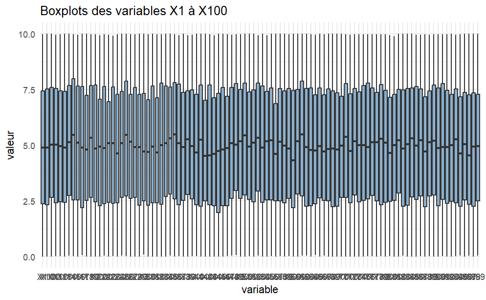

```r
library(ggplot2)

vars_cont <- colnames(reg_data)[1:100]

reg_data_long <- reg_data %>% dplyr::select(all_of(vars_cont)) %>% pivot_longer(cols = everything(), names_to = "variable", values_to = "valeur")

ggplot(reg_data_long, aes(x = variable, y = valeur)) +
  geom_boxplot(outlier.color = "red", fill = "steelblue", alpha = 0.6) +
  theme_minimal() +
  labs(title = "Boxplots des variables X1 à X100")
```

Pas de valeurs aberrantes. Distributions extrêmement uniformes et quasi-identiques entre les variables.

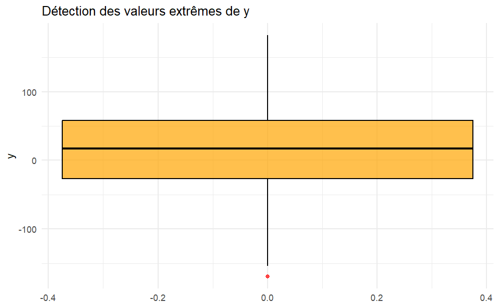

```r
ggplot(reg_data, aes(y = y)) +
  geom_boxplot(fill = "orange", color = "black", outlier.color = "red", alpha = 0.7) +
  theme_minimal() +
  labs(title = "Détection des valeurs extrêmes de y")
```

```r
# Calcul des seuils
Q1 <- quantile(reg_data$y, 0.25)
Q3 <- quantile(reg_data$y, 0.75)
IQR <- Q3 - Q1

seuil_inf <- Q1 - 1.5 * IQR
seuil_sup <- Q3 + 1.5 * IQR

# Identifier les valeurs aberrantes
outliers_y <- reg_data$y[reg_data$y < seuil_inf | reg_data$y > seuil_sup]
n_outliers <- length(outliers_y)
cat("Nombre de valeurs aberrantes de y :", n_outliers, "\n")
```

```
Nombre de valeurs aberrantes de y : 1
```

```r
# Afficher les valeurs et leurs indices
which_outliers <- which(reg_data$y < seuil_inf | reg_data$y > seuil_sup)
data.frame(Index = which_outliers, y = reg_data$y[which_outliers])
```

| Index | y |
| --- | --- |
| 57 | -168.989 |

On n’observe qu’une seule valeur abérrante pour y à l’indice 57.

#### Distributions

```r
library(tidyverse)
# Histogrammes
num_vars <- names(reg_data)[sapply(data, is.numeric)]

for (var in num_vars) {
  print(
    ggplot(reg_data, aes_string(x = var)) +
      geom_histogram(bins = 30, fill = "steelblue", color = "white") +
      labs(title = paste("Distribution de", var), x = var, y = "Fréquence") +
      theme_minimal()
  )
}
```

[output not shown]

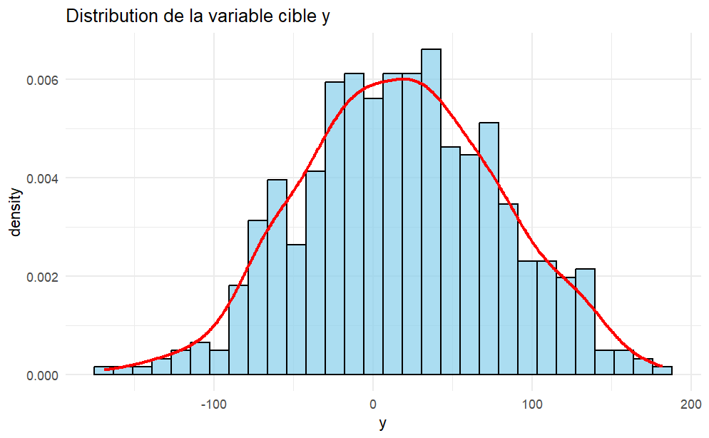

```r
# Histogramme et densité
ggplot(reg_data, aes(x = y)) +
  geom_histogram(aes(y = ..density..), bins = 30, fill = "skyblue", color = "black", alpha = 0.7) +
  geom_density(color = "red", size = 1) +
  theme_minimal() +
  labs(title = "Distribution de la variable cible y")
```

**y** semble suivre une **loi normale**.

#### Corrélations

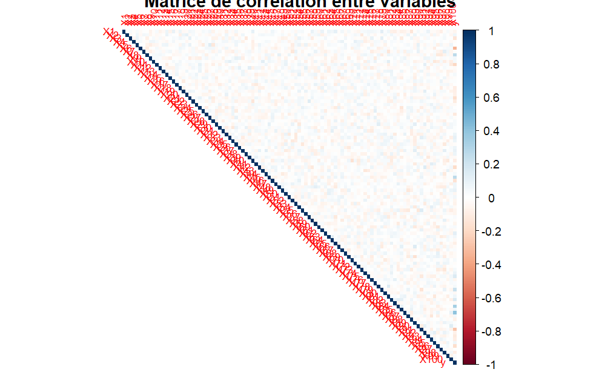

```r
library(corrplot)
# Matrice de corrélation
cor_mat <- cor(reg_data)
corrplot(cor_mat, method = "color", type = "upper", tl.cex = 0.7,
         title = "Matrice de corrélation entre variables")
```

```r
# Corrélation de chaque variable avec y
cor_y <- cor(reg_data %>% dplyr::select(-y), reg_data$y)
cor_y <- sort(cor_y, decreasing = TRUE)
print(cor_y)
```

```
  [1]  4.097174e-01  3.324641e-01  2.627620e-01  2.626151e-01  2.232349e-01  1.610699e-01  1.562706e-01  1.166686e-01
  [9]  1.088200e-01  9.209463e-02  9.177420e-02  8.870921e-02  7.684413e-02  7.508575e-02  7.350307e-02  7.167827e-02
 [17]  6.876055e-02  6.705868e-02  6.579583e-02  6.178996e-02  6.104031e-02  6.068380e-02  5.691227e-02  5.617763e-02
 [25]  5.516659e-02  5.234007e-02  4.887960e-02  4.527331e-02  4.493924e-02  4.210385e-02  4.047289e-02  4.009590e-02
 [33]  3.808376e-02  3.341368e-02  3.166294e-02  3.042665e-02  2.953586e-02  2.895584e-02  2.811218e-02  2.668901e-02
 [41]  2.578006e-02  2.348831e-02  1.783493e-02  1.541466e-02  1.385099e-02  1.110209e-02  5.949238e-03  2.723159e-03
 [49]  1.910528e-03 -8.837903e-05 -1.607409e-03 -1.027764e-02 -1.187186e-02 -1.290017e-02 -1.449417e-02 -1.506786e-02
 [57] -1.714522e-02 -1.784327e-02 -1.808617e-02 -1.969355e-02 -2.136530e-02 -2.180027e-02 -2.194290e-02 -2.277538e-02
 [65] -2.365879e-02 -2.485573e-02 -2.513506e-02 -2.653762e-02 -3.657682e-02 -3.730524e-02 -3.762105e-02 -3.777330e-02
 [73] -4.587320e-02 -5.256709e-02 -5.264042e-02 -5.447401e-02 -5.812078e-02 -5.958423e-02 -5.987746e-02 -6.841375e-02
 [81] -7.340947e-02 -7.497535e-02 -7.594350e-02 -8.559850e-02 -8.660702e-02 -9.328948e-02 -9.441279e-02 -9.525491e-02
 [89] -9.901043e-02 -1.068610e-01 -1.102763e-01 -1.168305e-01 -1.438319e-01 -1.536015e-01 -1.706611e-01 -1.758869e-01
 [97] -1.898729e-01 -2.020305e-01 -2.884504e-01 -3.464602e-01
```

```r
# Identifier les variables les plus explicatives (corrélation forte avec y)
top_vars <- names(cor_y)[1:6]
cat("Variables les plus corrélées positivement avec y :\n")
```

```
Variables les plus corrélées positivement avec y :
```

```r
print(top_vars)
```

[output not shown]

Les variables ne sont **pas corrélées** entre elles => aucune colinéarité, aucune redondance importante => aucun intérêt à utiliser Ridge

Par ailleurs, la plupart des variables explicatives ont peu ou pas de relation linéaire forte avec la variable cible y => **aucune relation linéaire marquée entre une seule variable et y**

#### Selection de variables

Création d’un jeu d’entrainement pour la sélection de variables

```r
set.seed(42)
train_size <- floor(0.7 * nrow(reg_data))
train_indices <- sample(seq_len(nrow(reg_data)), size = train_size)
reg_data_train <- reg_data[train_indices, ]
reg_data_test  <- reg_data[-train_indices, ]
```

##### Méthode forward

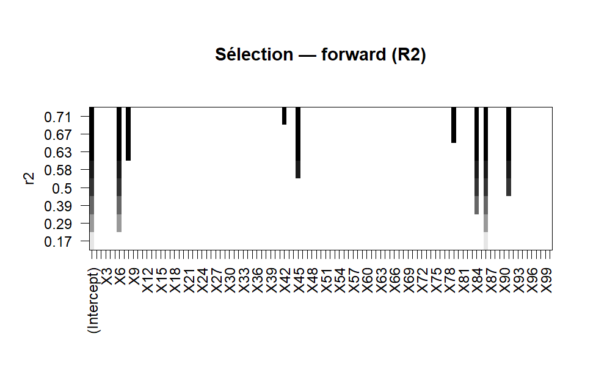

```r
library('leaps')
reg.forward <- regsubsets(y ~ . , data = reg_data, method = 'forward')
plot(reg.forward, scale = "r2", main = "Sélection — forward (R2)")
```

```r
forward.formula <- y ~ X6 + X8 + X42 + X45 + X79 + X84 + X86 + X91
```

y ~ X6 + X8 + X42 + X45 + X79 + X84 + X86 + X91

##### Méthode backward

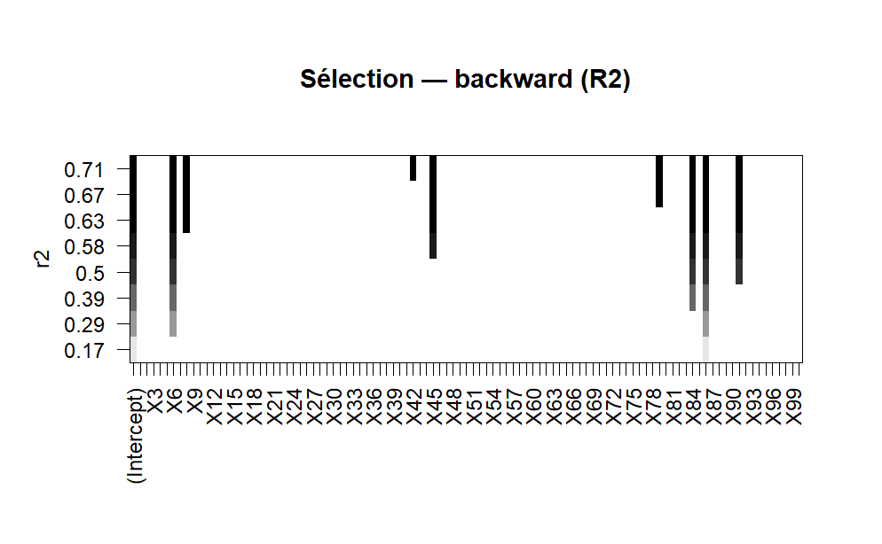

```r
library('leaps')
reg.backward <- regsubsets(y ~ . , data = reg_data, method = 'backward')
plot(reg.backward, scale = "r2", main = "Sélection — backward (R2)")
```

```r
backward.formula <- y ~ X6 + X8 + X42 + X45 + X79 + X84 + X86 + X91
```

y ~ X6 + X8 + X42 + X45 + X79 + X84 + X86 + X91

##### AIC

```r
library(MASS)
fit <- glm(y ~ .,data=reg_data, family = "gaussian")
sel.aic <- stepAIC(fit,scope=y ~ .,direction="both", trace=FALSE)
aic.formula <- formula(sel.aic)
print(formula(sel.aic))
```

```
y ~ X2 + X3 + X6 + X7 + X8 + X11 + X12 + X14 + X16 + X17 + X18 +
    X19 + X20 + X21 + X22 + X23 + X25 + X27 + X29 + X31 + X33 +
    X34 + X35 + X36 + X37 + X40 + X41 + X42 + X43 + X44 + X45 +
    X46 + X49 + X50 + X52 + X56 + X57 + X58 + X60 + X62 + X64 +
    X68 + X71 + X72 + X73 + X74 + X75 + X77 + X78 + X79 + X80 +
    X81 + X82 + X84 + X85 + X86 + X90 + X91 + X93 + X94 + X96 +
    X97 + X98 + X99 + X100
```

```r
library(MASS)
fit <- glm(y ~ .,data=reg_data, family = "gaussian")
sel.bic <- stepAIC(fit,scope=y ~ .,direction="both",
k=log(nrow(reg_data)), trace= FALSE)
bic.formula <- formula(sel.bic)
print(formula(sel.bic))
```

```
y ~ X2 + X3 + X6 + X7 + X8 + X11 + X12 + X16 + X17 + X18 + X19 +
    X20 + X21 + X22 + X25 + X33 + X34 + X35 + X36 + X37 + X40 +
    X41 + X42 + X43 + X44 + X45 + X46 + X49 + X50 + X52 + X56 +
    X57 + X58 + X62 + X71 + X72 + X73 + X74 + X75 + X79 + X80 +
    X81 + X84 + X85 + X86 + X90 + X91 + X93 + X94 + X96 + X98
```

##### Valider les sélections

```r
library(MASS)
model.reg <- glm(y ~ ., data=reg_data_train, family="gaussian")
model.reg.aic <- glm(aic.formula, data=reg_data_train, family="gaussian")
model.reg.bic <- glm(bic.formula, data=reg_data_train, family="gaussian")
model.reg.forward <- glm(forward.formula, data=reg_data_train, family="gaussian")
model.reg.backward <- glm(backward.formula, data=reg_data_train, family="gaussian")

pred.reg <- predict(model.reg, newdata=reg_data_test, type="response")
pred.reg.aic <- predict(model.reg.aic, newdata=reg_data_test, type="response")
pred.reg.bic <- predict(model.reg.bic, newdata=reg_data_test, type="response")
pred.reg.forward <- predict(model.reg.forward, newdata=reg_data_test, type="response")
pred.reg.backward <- predict(model.reg.backward, newdata=reg_data_test, type="response")

# Calcul du MSE
mse.reg <- mean((reg_data_test$y - pred.reg)^2)
mse.reg.aic <- mean((reg_data_test$y - pred.reg.aic)^2)
mse.reg.bic <- mean((reg_data_test$y - pred.reg.bic)^2)
mse.reg.forward <- mean((reg_data_test$y - pred.reg.forward)^2)
mse.reg.backward <- mean((reg_data_test$y - pred.reg.backward)^2)

cat("\n============RESULTATS SELECTION DE VARIABLES============\n")
```

```
============RESULTATS SELECTION DE VARIABLES============
```

```r
cat("\n====Regression logistique avec toutes les variables====\n")
```

```
====Regression logistique avec toutes les variables====
```

```r
cat("MSE: ", mse.reg, "RMSE", sqrt(mse.reg), "\nformule :", "complete", "\n")
```

```
MSE:  186.289 RMSE 13.64877
formule : complete
```

```r
cat("\n====Regression logistique avec selection de variables par AIC====\n")
```

```
====Regression logistique avec selection de variables par AIC====
```

```r
cat("MSE: ", mse.reg.aic,"RMSE", sqrt(mse.reg.aic), "\nformule ", as.character(aic.formula)[3], "\n")
```

```
MSE:  152.1829 RMSE 12.33624
formule  X2 + X3 + X6 + X7 + X8 + X11 + X12 + X14 + X16 + X17 + X18 + X19 + X20 + X21 + X22 + X23 + X25 + X27 + X29 + X31 + X33 + X34 + X35 + X36 + X37 + X40 + X41 + X42 + X43 + X44 + X45 + X46 + X49 + X50 + X52 + X56 + X57 + X58 + X60 + X62 + X64 + X68 + X71 + X72 + X73 + X74 + X75 + X77 + X78 + X7…
```

```r
cat("\n====Regression logistique avec selection de variables par BIC====\n")
```

```
====Regression logistique avec selection de variables par BIC====
```

```r
cat("MSE : ", mse.reg.bic, "RMSE", sqrt(mse.reg.bic),"\nformule ", as.character(bic.formula)[3] , "\n")
```

```
MSE :  164.6887 RMSE 12.83311
formule  X2 + X3 + X6 + X7 + X8 + X11 + X12 + X16 + X17 + X18 + X19 + X20 + X21 + X22 + X25 + X33 + X34 + X35 + X36 + X37 + X40 + X41 + X42 + X43 + X44 + X45 + X46 + X49 + X50 + X52 + X56 + X57 + X58 + X62 + X71 + X72 + X73 + X74 + X75 + X79 + X80 + X81 + X84 + X85 + X86 + X90 + X91 + X93 + X94 + X9…
```

```r
cat("\n====Regression logistique avec selection de variables par méthode forward====\n")
```

```
====Regression logistique avec selection de variables par méthode forward====
```

```r
cat("MSE : ", mse.reg.forward,"RMSE", sqrt(mse.reg.forward),"\nformule ", "y ~ X6 + X8 + X42 + X45 + X79 + X84 + X86 + X91" , "\n")
```

```
MSE :  1120.982 RMSE 33.48107
formule  y ~ X6 + X8 + X42 + X45 + X79 + X84 + X86 + X91
```

```r
cat("\n====Regression logistique avec selection de variables par méthode backward====\n")
```

```
====Regression logistique avec selection de variables par méthode backward====
```

```r
cat("MSE : ", mse.reg.backward,"RMSE", sqrt(mse.reg.backward), "\nformule ", "y ~ X6 + X8 + X42 + X45 + X79 + X84 + X86 + X91" , "\n")
```

```
MSE :  1120.982 RMSE 33.48107
formule  y ~ X6 + X8 + X42 + X45 + X79 + X84 + X86 + X91
```

À l’inverse, les méthodes stepwise forward et backward conduisent toutes deux à une MSE extrêmement élevée. Cela indique un sous-ajustement important : le nombre de variables retenues est trop faible pour capturer correctement la structure du problème, ce qui dégrade fortement la qualité des prédictions. Ces approches apparaissent donc inadaptées dans ce contexte.

Globalement, la sélection par AIC et BIC se révèle plus pertinente et plus stable, tandis que les approches stepwise classiques doivent être évitées ici/

#### Tests de régresseurs

Au vu des données, les deux meilleurs classifieurs devraient être la régression linéaire et LASSO.

##### Régression linéaire

```r
library(dplyr)

set.seed(123)

# Préparation des données
n <- nrow(reg_data)

# Validation croisée 10-fold
k <- 10
folds <- sample(rep(1:k, length.out = n))

rmse_fold <- function(y_true, y_pred) {
  sqrt(mean((y_true - y_pred)^2))
}

rmse_results <- numeric(k)
rmse_results_aic <- numeric(k)
rmse_results_bic <- numeric(k)

for (i in 1:k) {
  test_idx <- which(folds == i)
  train_idx <- setdiff(1:n, test_idx)

  train_df <- reg_data[train_idx, ]
  test_df <- reg_data[test_idx, ]

  # Régression linéaire
  lm_mod <- lm(y ~ ., data = train_df)
  lm_mod_aic <- lm(aic.formula, data = train_df)
  lm_mod_bic <- lm(bic.formula, data = train_df)

  # Prédiction
  pred <- predict(lm_mod, newdata = test_df)
  pred_aic <- predict(lm_mod_aic, newdata = test_df)
  pred_bic <- predict(lm_mod_bic, newdata = test_df)

  # RMSE
  rmse_results[i] <- rmse_fold(test_df$y, pred)
  rmse_results_aic[i] <- rmse_fold(test_df$y, pred_aic)
  rmse_results_bic[i] <- rmse_fold(test_df$y, pred_bic)
}

# Résultats
mean_rmse <- mean(rmse_results)
sd_rmse <- sd(rmse_results)

mean_rmse_aic <- mean(rmse_results_aic)
sd_rmse_aic <- sd(rmse_results_aic)

mean_rmse_bic <- mean(rmse_results_bic)
sd_rmse_bic <- sd(rmse_results_bic)

cat("RMSE moyen :", mean_rmse, "\n")
```

```
RMSE moyen : 12.42797
```

```r
cat("Écart-type du RMSE :", sd_rmse, "\n")
```

```
Écart-type du RMSE : 1.157132
```

```r
cat("RMSE moyen avec formule AIC :", mean_rmse_aic, "\n")
```

```
RMSE moyen avec formule AIC : 11.66066
```

```r
cat("Écart-type du RMSE avec formule AIC :", sd_rmse_aic, "\n")
```

```
Écart-type du RMSE avec formule AIC : 0.8863229
```

```r
cat("RMSE moyen avec formule BIC :", mean_rmse_bic, "\n")
```

```
RMSE moyen avec formule BIC : 11.94118
```

```r
cat("Écart-type du RMSE avec formule BIC :", sd_rmse_bic, "\n")
```

```
Écart-type du RMSE avec formule BIC : 0.7520975
```

Les résultats montrent que les modèles sélectionnés par AIC et BIC offrent un RMSE moyen légèrement inférieur et plus stable que le modèle complet, indiquant qu’une sélection de variables améliore ici modestement la précision et la robustesse de la régression linéaire.

##### LASSO

Le jeu de données contient bcp de variables, surtout par rapport au nombre d’observations. Il peut donc être intéressant d’utiliser LASSO pour faire de la sélection de variables. (Aucun intérêt ici à utiliser Ridge ou elastic net)

```r
# Préparation
library(glmnet)
```

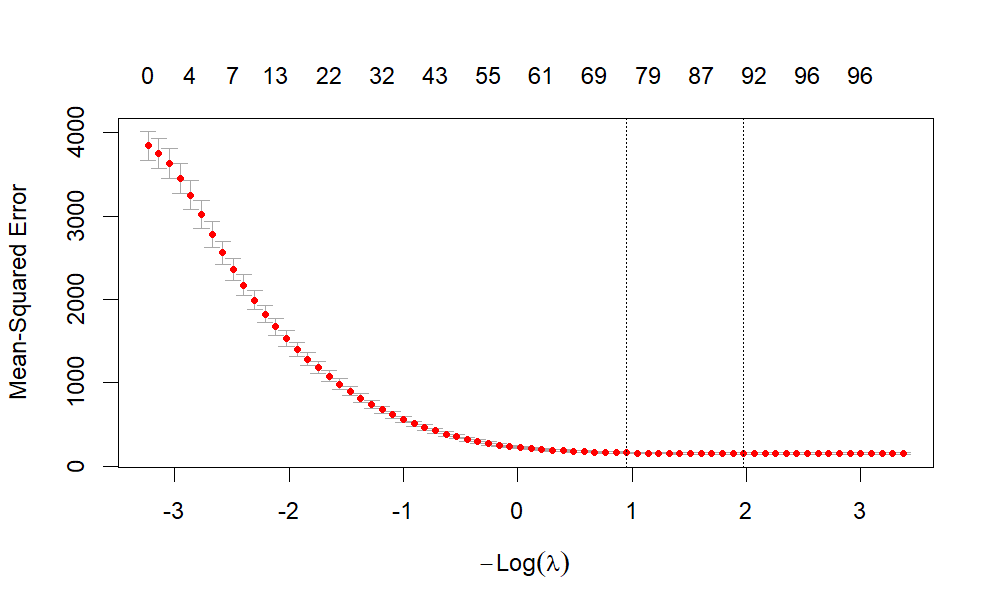

```r
X <- as.matrix(dplyr::select(reg_data, -y))
y <- reg_data$y

# Traitement de l’outlier
y_no_outlier <- y[y > quantile(y, 0.01)]

# Validation croisée LASSO
set.seed(123)
cv_lasso <- cv.glmnet(X, y, alpha = 1, standardize = TRUE)
plot(cv_lasso)
```

```r
# Coefficients retenus
coff <- coef(cv_lasso, s = "lambda.min")

# Évaluation
pred <- predict(cv_lasso, newx = X, s = "lambda.min")
R2 <- cor(pred, y)^2
rmse_lasso <- sqrt(mean((y - pred)^2))
cat("R² =", R2)
```

```
R² = 0.9737215
```

```r
cat("\nRMSE", rmse_lasso)
```

```
RMSE 10.06987
```

LASSO utilise globalement toutes les variables (sauf X1, X4, X28, X54, X63, X65, X66, X69, X86).  
R² = 0.9737215 RMSE 10.06987, ce qui est plus faible que la régression linéaire avec AIC

##### Comparaison de tous les modèles de régression

```r
library(glmnet)
library(randomForest)
library(xgboost)
library(dplyr)
library(splines)
library(mgcv)
library(autogam)
library(rpart)

set.seed(123)

# Préparation des données
X <- as.matrix(dplyr::select(reg_data, -y))
y <- reg_data$y

# Standardisation pour modèles linéaires régularisés
X_scaled <- scale(X)



# Validation croisée 10-fold
k <- 5
folds <- sample(rep(1:k, length.out = nrow(X_scaled)))

rmse_fold <- function(y_true, y_pred) {
  sqrt(mean((y_true - y_pred)^2))
}
mse_fold <- function(y_true, y_pred) {
  mean((y_true - y_pred)^2)
}

# Stockage des RMSE
results <- list(LM = numeric(k),
                #LM_AIC = numeric(k),
                #LM_BIC = numeric(k),
                Ridge = numeric(k),
                Lasso = numeric(k),
                RF = numeric(k),
                XGB = numeric(k),
                SPLGAM = numeric(k),
                REGTREE = numeric(k),
                PRUNED_REGTREE = numeric(k))


for (i in 1:k) {
  test_idx <- which(folds == i)
  train_idx <- setdiff(1:nrow(X_scaled), test_idx)

  X_train <- X_scaled[train_idx, , drop = FALSE]
  y_train <- y[train_idx]
  X_test <- X_scaled[test_idx, , drop = FALSE]
  y_test <- y[test_idx]


  # Régression linéaire
  train_df <- data.frame(y = y_train, X_train)
  colnames(train_df)[-1] <- colnames(reg_data)[-ncol(reg_data)]

  test_df <- data.frame(X_test)
  colnames(test_df) <- colnames(train_df)[-1]

  lm_mod <- lm(y ~ ., data = train_df)
  pred_lm <- predict(lm_mod, newdata = test_df)
  #results$LM[i] <- rmse_fold(y_test, pred_lm)
  results$LM[i] <- mse_fold(y_test, pred_lm)

  #avec AIC
  #lm_mod_aic <- lm(aic.formula, data = train_df)
  #pred_lm_aic <- predict(lm_mod_aic, newdata = test_df)
  #results$LM_AIC[i] <- rmse_fold(y_test, pred_lm_aic)
  #results$LM_AIC[i] <- mse_fold(y_test, pred_lm_aic)

  #avec BIC
  #lm_mod_bic <- lm(bic.formula, data = train_df)
  #pred_lm_bic <- predict(lm_mod_bic, newdata = test_df)
  #results$LM_BIC[i] <- rmse_fold(y_test, pred_lm_bic)
  #results$LM_BIC[i] <- mse_fold(y_test, pred_lm_bic)


  # Splines + GAM
  #splgam_mod <- autogam(data=train_df,y_col="y")
  #pred_splgam <- predict(splgam_mod, test_df, type = "response")
  #results$SPLGAM[i] <- rmse_fold(y_test, pred_splgam)
  #results$SPLGAM[i] <- mse_fold(y_test, pred_splgam)

  # Ridge
  ridge_mod <- cv.glmnet(X_train, y_train, alpha = 0, nfolds = 5)
  pred_ridge <- predict(ridge_mod, X_test, s = "lambda.min")
  #results$Ridge[i] <- rmse_fold(y_test, pred_ridge)
  results$Ridge[i] <- mse_fold(y_test, pred_ridge)

  # Lasso
  lasso_mod <- cv.glmnet(X_train, y_train, alpha = 1, nfolds = 5)
  pred_lasso <- predict(lasso_mod, X_test, s = "lambda.min") # Test 1se lambda
  #results$Lasso[i] <- rmse_fold(y_test, pred_lasso)
  results$Lasso[i] <- mse_fold(y_test, pred_lasso)

  # Random Forest
  rf_mod <- randomForest(x = X_train, y = y_train, ntree = 200)
  pred_rf <- predict(rf_mod, X_test)
  #results$RF[i] <- rmse_fold(y_test, pred_rf)
  results$RF[i] <- mse_fold(y_test, pred_rf)

  # XGBoost
  #xgb_train <- xgb.DMatrix(data = X_train, label = y_train)
  #xgb_test <- xgb.DMatrix(data = X_test, label = y_test)
  #xgb_mod <- xgboost(data = xgb_train, nrounds = 100, objective = "reg:squarederror", verbose = 0)
  #pred_xgb <- predict(xgb_mod, xgb_test)
  # results$XGB[i] <- rmse_fold(y_test, pred_xgb)
  #results$XGB[i] <- mse_fold(y_test, pred_xgb)

  # Regression Tree + pruned
  tree_mod <- rpart(y ~ ., data=train_df, method="anova",control = rpart.control(minbucket = 10, cp = 0))
  pred_tree <- predict(tree_mod, newdata=test_df)
  # results$REGTREE[i] <- rmse_fold(y_test, pred_tree)
  results$REGTREE[i] <- mse_fold(y_test, pred_tree)
    # pruning tree
  i_min <- which.min(tree_mod$cptable[, 4])
  x <- tree_mod$cptable[i_min, 4] + tree_mod$cptable[i_min, 5]
  ii <- which(tree_mod$cptable[, 4] <= x)
  cp_opt <- tree_mod$cptable[min(ii), 1]
  pruned_tree <- prune(tree_mod, cp=cp_opt)
  pred_tree_pruned <- predict(pruned_tree, newdata=test_df)
  #results$PRUNED_REGTREE[i] <- rmse_fold(y_test, pred_tree_pruned)
  results$PRUNED_REGTREE[i] <- mse_fold(y_test, pred_tree_pruned)
}


# Comparaison
mean_mse <- sapply(results, mean)
sd_mse <- sapply(results, sd)

res_df <- data.frame(Model = names(mean_mse),
                     MSE_Mean = mean_mse,
                     MSE_SD = sd_mse)
print(res_df)
```

|  | Model | MSE_Mean | MSE_SD |
| --- | --- | --- | --- |
| LM | LM | 162.7604 | 24.44897 |
| Ridge | Ridge | 172.3437 | 21.73948 |
| Lasso | Lasso | 158.6060 | 18.59607 |
| RF | RF | 2104.7155 | 311.13204 |
| XGB | XGB | 0.0000 | 0.00000 |
| SPLGAM | SPLGAM | 0.0000 | 0.00000 |
| REGTREE | REGTREE | 2930.5635 | 445.46835 |
| PRUNED_REGTREE | PRUNED_REGTREE | 3181.6385 | 544.54756 |

```r
# Meilleur modèle
best_model <- res_df$Model[which.min(res_df$MSE_Mean)]
cat("\nMeilleur modèle selon RMSE moyen :", best_model, "\n")
```

```
Meilleur modèle selon RMSE moyen : XGB
```

```r
library(glmnet)
library(randomForest)
library(xgboost)
library(dplyr)
library(splines)
library(mgcv)
library(autogam)
library(rpart)
library(tidyverse)
set.seed(123)

# Préparation des données
X <- reg_data %>% dplyr::select(-y) %>% as.matrix()
y <- reg_data$y

# Standardisation pour modèles linéaires régularisés
X_scaled <- scale(X)

# Validation croisée 5-fold
k <- 10
folds <- sample(rep(1:k, length.out = nrow(X_scaled)))

rmse_fold <- function(y_true, y_pred) {
  sqrt(mean((y_true - y_pred)^2))
}
mse_fold <- function(y_true, y_pred) {
  mean((y_true - y_pred)^2)
}

# Stockage des MSE
results <- list(
  LM = numeric(k),
  Ridge = numeric(k),
  Lasso = numeric(k),
  Lasso_Opt = numeric(k),
  Lasso_Sq = numeric(k),
  Lasso_Sqrt = numeric(k),
  Lasso_Log = numeric(k)
)

for (i in 1:k) {
  test_idx <- which(folds == i)
  train_idx <- setdiff(1:nrow(X_scaled), test_idx)

  X_train <- X_scaled[train_idx, , drop = FALSE]
  y_train <- y[train_idx]
  X_test <- X_scaled[test_idx, , drop = FALSE]
  y_test <- y[test_idx]

  # Transformation des variables pour LASSO
  X_train_sq <- X_train^2
  X_test_sq <- X_test^2

  X_train_sqrt <- sqrt(pmax(X_train, 0))
  X_test_sqrt <- sqrt(pmax(X_test, 0))

  X_train_log <- log(pmax(X_train, 1e-6))
  X_test_log <- log(pmax(X_test, 1e-6))

  # Préparation des data.frames pour LM, GAM, arbre
  train_df <- data.frame(y = y_train, X_train)
  colnames(train_df)[-1] <- colnames(reg_data)[-ncol(reg_data)]

  test_df <- data.frame(X_test)
  colnames(test_df) <- colnames(train_df)[-1]

  # Régression linéaire
  lm_mod <- lm(y ~ ., data = train_df)
  pred_lm <- predict(lm_mod, newdata = test_df)
  results$LM[i] <- mse_fold(y_test, pred_lm)

  # Ridge
  ridge_mod <- cv.glmnet(X_train, y_train, alpha = 0, nfolds = 5)
  pred_ridge <- predict(ridge_mod, X_test, s = "lambda.min")
  results$Ridge[i] <- mse_fold(y_test, pred_ridge)

  # Lasso standard
  lasso_mod <- cv.glmnet(X_train, y_train, alpha = 1, nfolds = 5)
  pred_lasso <- predict(lasso_mod, X_test, s = "lambda.min")
  results$Lasso[i] <- mse_fold(y_test, pred_lasso)

  # Lasso opti
  lasso_cv <- cv.glmnet(X_train, y_train, alpha = 1, nfolds = 5)
  pred_lasso_min <- predict(lasso_cv, X_test, s = "lambda.min")
  pred_lasso_1se <- predict(lasso_cv, X_test, s = "lambda.1se")

  mse_min <- mse_fold(y_test, pred_lasso_min)
  mse_1se <- mse_fold(y_test, pred_lasso_1se)

  if (mse_min <= mse_1se) {
    results$Lasso_Opt[i] <- mse_min
  } else {
    results$Lasso_Opt[i] <- mse_1se
  }

  # Lasso carré
  lasso_sq_mod <- cv.glmnet(X_train_sq, y_train, alpha = 1, nfolds = 5)
  pred_lasso_sq <- predict(lasso_sq_mod, X_test_sq, s = "lambda.min")
  results$Lasso_Sq[i] <- mse_fold(y_test, pred_lasso_sq)

  # Lasso racine
  lasso_sqrt_mod <- cv.glmnet(X_train_sqrt, y_train, alpha = 1, nfolds = 5)
  pred_lasso_sqrt <- predict(lasso_sqrt_mod, X_test_sqrt, s = "lambda.min")
  results$Lasso_Sqrt[i] <- mse_fold(y_test, pred_lasso_sqrt)

  # Lasso log
  lasso_log_mod <- cv.glmnet(X_train_log, y_train, alpha = 1, nfolds = 5)
  pred_lasso_log <- predict(lasso_log_mod, X_test_log, s = "lambda.min")
  results$Lasso_Log[i] <- mse_fold(y_test, pred_lasso_log)
}

# Comparaison
mean_mse <- sapply(results, mean)
sd_mse <- sapply(results, sd)

res_df <- data.frame(Model = names(mean_mse),
                     MSE_Mean = mean_mse,
                     MSE_SD = sd_mse)
print(res_df)
```

|  | Model | MSE_Mean | MSE_SD |
| --- | --- | --- | --- |
| LM | LM | 155.6596 | 28.95486 |
| Ridge | Ridge | 164.8626 | 29.47394 |
| Lasso | Lasso | 152.3360 | 25.28923 |
| Lasso_Opt | Lasso_Opt | 150.9806 | 24.57595 |
| Lasso_Sq | Lasso_Sq | 3878.3630 | 534.62821 |
| Lasso_Sqrt | Lasso_Sqrt | 752.9836 | 203.13450 |
| Lasso_Log | Lasso_Log | 1079.6665 | 259.08479 |

```r
# Meilleur modèle
best_model <- res_df$Model[which.min(res_df$MSE_Mean)]
cat("\nMeilleur modèle selon MSE moyen :", best_model, "\n")
```

```
Meilleur modèle selon MSE moyen : Lasso_Opt
```

utiliser lasso avec x et x^2 pour identifier les carrés d’intérêt puis mélange => Camille regarder tous les splines appris 1 à 1 => Bastien

##### Test transformations

```r
library(glmnet)
library(dplyr)

set.seed(123)

# Données
X <- reg_data %>% dplyr::select(-y) %>% as.matrix()
y <- reg_data$y
X_scaled <- scale(X)

varnames <- colnames(X_scaled)

# Transformations
X_sq    <- X_scaled^2
X_sqrt  <- sqrt(pmax(X_scaled, 0))
X_log   <- log(pmax(X_scaled, 1e-6))

test_var <- function(x_base, x_sq, x_sqrt, x_log, y) {

  safe_cv <- function(vec, y) {

    # Reforce matrice
    Xmat <- matrix(vec, ncol = 1)

    # Variance nulle marche pas avec glmnet
    if (sd(Xmat) == 0) return(Inf)

    # ajouter une colonne factice => permet de débugger à améliorer plus tard
    Xmat2 <- cbind(Xmat, 0)

    # LASSO
    cv <- cv.glmnet(Xmat2, y, alpha = 1)
    return(min(cv$cvm))
  }

  mse_list <- c(
    base = safe_cv(x_base, y),
    sq   = safe_cv(x_sq, y),
    sqrt = safe_cv(x_sqrt, y),
    log  = safe_cv(x_log, y)
  )

  names(which.min(mse_list))
}


best_transform <- sapply(
  seq_along(varnames),
  function(j) test_var(
    X_scaled[, j, drop = FALSE][,1],
    X_sq[, j, drop = FALSE][,1],
    X_sqrt[, j, drop = FALSE][,1],
    X_log[, j, drop = FALSE][,1],
    y
  )
)

names(best_transform) <- varnames
best_transform
```

```
    X1     X2     X3     X4     X5     X6     X7     X8     X9    X10    X11    X12    X13    X14    X15    X16    X17    X18
"base"   "sq"  "log" "base"   "sq" "base"  "log" "sqrt" "sqrt"   "sq" "sqrt" "sqrt"   "sq"   "sq"   "sq"   "sq"   "sq"  "log"
   X19    X20    X21    X22    X23    X24    X25    X26    X27    X28    X29    X30    X31    X32    X33    X34    X35    X36
 "log" "sqrt" "sqrt" "base"   "sq"   "sq"  "log" "sqrt" "sqrt" "sqrt" "sqrt"  "log" "base" "base" "base" "sqrt" "base"  "log"
   X37    X38    X39    X40    X41    X42    X43    X44    X45    X46    X47    X48    X49    X50    X51    X52    X53    X54
"base" "base" "sqrt" "sqrt" "sqrt" "base" "base" "sqrt" "sqrt" "base"  "log" "base" "sqrt"   "sq"  "log"   "sq"  "log"   "sq"
   X55    X56    X57    X58    X59    X60    X61    X62    X63    X64    X65    X66    X67    X68    X69    X70    X71    X72
 "log"   "sq" "base"  "log"  "log"  "log" "base" "base" "base"   "sq"  "log" "sqrt"   "sq" "base"  "log"   "sq"  "log"   "sq"
   X73    X74    X75    X76    X77    X78    X79    X80    X81    X82    X83    X84    X85    X86    X87    X88    X89    X90
 "log"  "log" "base" "base"   "sq" "base" "base"  "log"  "log" "sqrt"  "log" "base"  "log" "base"  "log" "sqrt"   "sq"   "sq"
   X91    X92    X93    X94    X95    X96    X97    X98    X99   X100
"sqrt" "base" "base" "sqrt" "base" "sqrt" "base"  "log"   "sq" "base"
```

```r
df_final <- data.frame(y = y)

for (j in seq_along(varnames)) {

  v <- varnames[j]

  if (best_transform[v] == "base")
    df_final[[v]] <- X_scaled[, j]

  if (best_transform[v] == "sq")
    df_final[[v]] <- X_sq[, j]

  if (best_transform[v] == "sqrt")
    df_final[[v]] <- X_sqrt[, j]

  if (best_transform[v] == "log")
    df_final[[v]] <- X_log[, j]
}
```

```r
formula_final <- as.formula(
  paste("y ~", paste(colnames(df_final)[-1], collapse = " + "))
)

formula_final
```

```
y ~ X1 + X2 + X3 + X4 + X5 + X6 + X7 + X8 + X9 + X10 + X11 +
    X12 + X13 + X14 + X15 + X16 + X17 + X18 + X19 + X20 + X21 +
    X22 + X23 + X24 + X25 + X26 + X27 + X28 + X29 + X30 + X31 +
    X32 + X33 + X34 + X35 + X36 + X37 + X38 + X39 + X40 + X41 +
    X42 + X43 + X44 + X45 + X46 + X47 + X48 + X49 + X50 + X51 +
    X52 + X53 + X54 + X55 + X56 + X57 + X58 + X59 + X60 + X61 +
    X62 + X63 + X64 + X65 + X66 + X67 + X68 + X69 + X70 + X71 +
    X72 + X73 + X74 + X75 + X76 + X77 + X78 + X79 + X80 + X81 +
    X82 + X83 + X84 + X85 + X86 + X87 + X88 + X89 + X90 + X91 +
    X92 + X93 + X94 + X95 + X96 + X97 + X98 + X99 + X100
```

```r
mod_final_lm <- lm(formula_final, data = df_final)
summary(mod_final_lm)
```

```
Call:
lm(formula = formula_final, data = df_final)

Residuals:
    Min      1Q  Median      3Q     Max
-54.693 -13.188   0.321  13.545  51.876

Coefficients:
             Estimate Std. Error t value Pr(>|t|)
(Intercept)  41.66489    9.47475   4.397 1.41e-05 ***
X1           -1.54489    1.10869  -1.393 0.164262
X2           -2.33977    1.23940  -1.888 0.059774 .
X3           -1.03906    0.16469  -6.309 7.46e-10 ***
X4            0.77633    1.08176   0.718 0.473387
X5           -0.72579    1.22966  -0.590 0.555367
X6          -18.93765    1.09198 -17.343  < 2e-16 ***
X7            0.53298    0.16335   3.263 0.001199 **
X8           22.42063    2.28794   9.799  < 2e-16 ***
X9           -0.84388    2.20451  -0.383 0.702076
X10           0.51298    1.26606   0.405 0.685562
X11         -15.15886    2.20711  -6.868 2.50e-11 ***
X12          -3.87431    2.21060  -1.753 0.080438 .
X13          -0.57219    1.18918  -0.481 0.630667
X14          -0.67879    1.22256  -0.555 0.579056
X15           1.64149    1.29506   1.268 0.205714
X16          -0.57361    1.26417  -0.454 0.650259
X17          -0.98848    1.31347  -0.753 0.452150
X18          -0.47388    0.15991  -2.963 0.003225 **
X19          -0.83874    0.16214  -5.173 3.65e-07 ***
X20          -1.25765    2.18776  -0.575 0.565712
X21         -15.02719    2.23833  -6.714 6.55e-11 ***
X22          -5.80351    1.08473  -5.350 1.48e-07 ***
X23          -1.90129    1.29475  -1.468 0.142767
X24           0.98846    1.19789   0.825 0.409769
X25           0.59020    0.16383   3.603 0.000355 ***
X26          -3.37261    2.26853  -1.487 0.137884
X27           3.73098    2.21746   1.683 0.093245 .
X28           1.31671    2.29711   0.573 0.566831
X29          -0.13342    2.23820  -0.060 0.952495
X30           0.05312    0.16142   0.329 0.742256
```

[output cut: 61 more lines]

```
X92           0.07634    1.09581   0.070 0.944495
X93          -4.56071    1.08995  -4.184 3.52e-05 ***
X94         -10.26389    2.22149  -4.620 5.18e-06 ***
X95          -0.29915    1.10851  -0.270 0.787403
X96         -17.11829    2.29043  -7.474 4.98e-13 ***
X97           3.26302    1.08095   3.019 0.002702 **
X98          -0.99159    0.16884  -5.873 9.03e-09 ***
X99          -0.83948    1.20342  -0.698 0.485847
X100          2.11939    1.08900   1.946 0.052335 .
---
Signif. codes:  0 ‘***’ 0.001 ‘**’ 0.01 ‘*’ 0.05 ‘.’ 0.1 ‘ ’ 1

Residual standard error: 21.77 on 399 degrees of freedom
Multiple R-squared:  0.9014,    Adjusted R-squared:  0.8767
F-statistic: 36.47 on 100 and 399 DF,  p-value: < 2.2e-16
```

```r
X_final <- as.matrix(df_final %>% dplyr::select(-y))

mod_final_lasso <- cv.glmnet(X_final, y, alpha = 1)

mse_final_lasso <- min(mod_final_lasso$cvm)
rmse_final_lasso <- sqrt(mse_final_lasso)

mse_final_lasso
```

```
[1] 574.7388
```

```r
rmse_final_lasso
```

```
[1] 23.97371
```

On se rend compte qu’il y a un problème d’échelle donc ci-dessous voici la version avec scale après les transformations :

```r
library(glmnet)
library(dplyr)

set.seed(123)

# Données de départ
X <- reg_data %>% dplyr::select(-y) %>% as.matrix()
y <- reg_data$y

# Standardisation initiale
X_scaled <- scale(X)
varnames <- colnames(X_scaled)
X_sq    <- X_scaled^2
X_sqrt  <- sqrt(pmax(X_scaled, 0))
X_log   <- log(pmax(X_scaled, 1e-6))

test_var <- function(x_base, x_sq, x_sqrt, x_log, y) {

  safe_cv <- function(vec, y) { # à modifier plus tard, function créée pour l'instant pour résoudre le bug => bricolage...
    Xmat <- matrix(vec, ncol = 1)
    if (sd(Xmat) == 0) return(Inf)
    Xmat2 <- cbind(Xmat, 0)

    cv <- cv.glmnet(Xmat2, y, alpha = 1)
    min(cv$cvm)
  }

  mse_list <- c(
    base = safe_cv(x_base,  y),
    sq   = safe_cv(x_sq,    y),
    sqrt = safe_cv(x_sqrt,  y),
    log  = safe_cv(x_log,   y)
  )

  names(which.min(mse_list))
}


best_transform <- sapply(
  seq_along(varnames),
  function(j) test_var(
    X_scaled[, j],
    X_sq[, j],
    X_sqrt[, j],
    X_log[, j],
    y
  )
)

names(best_transform) <- varnames
best_transform
```

```
    X1     X2     X3     X4     X5     X6     X7     X8     X9    X10    X11    X12    X13    X14    X15    X16    X17    X18
"base"   "sq"  "log" "base"   "sq" "base"  "log" "sqrt" "sqrt"   "sq" "sqrt" "sqrt"   "sq"   "sq"   "sq"   "sq"   "sq"  "log"
   X19    X20    X21    X22    X23    X24    X25    X26    X27    X28    X29    X30    X31    X32    X33    X34    X35    X36
 "log" "sqrt" "sqrt" "base"   "sq"   "sq"  "log" "sqrt" "sqrt" "sqrt" "sqrt"  "log" "base" "base" "base" "sqrt" "base"  "log"
   X37    X38    X39    X40    X41    X42    X43    X44    X45    X46    X47    X48    X49    X50    X51    X52    X53    X54
"base" "base" "sqrt" "sqrt" "sqrt" "base" "base" "sqrt" "sqrt" "base"  "log" "base" "sqrt"   "sq"  "log"   "sq"  "log"   "sq"
   X55    X56    X57    X58    X59    X60    X61    X62    X63    X64    X65    X66    X67    X68    X69    X70    X71    X72
 "log"   "sq" "base"  "log"  "log"  "log" "base" "base" "base"   "sq"  "log" "sqrt"   "sq" "base"  "log"   "sq"  "log"   "sq"
   X73    X74    X75    X76    X77    X78    X79    X80    X81    X82    X83    X84    X85    X86    X87    X88    X89    X90
 "log"  "log" "base" "base"   "sq" "base" "base"  "log"  "log" "sqrt"  "log" "base"  "log" "base"  "log" "sqrt"   "sq"   "sq"
   X91    X92    X93    X94    X95    X96    X97    X98    X99   X100
"sqrt" "base" "base" "sqrt" "base" "sqrt" "base"  "log"   "sq" "base"
```

```r
df_final <- data.frame(y = y)

for (j in seq_along(varnames)) {

  v <- varnames[j]

  if (best_transform[v] == "base")
    df_final[[v]] <- X_scaled[, j]

  if (best_transform[v] == "sq")
    df_final[[v]] <- X_sq[, j]

  if (best_transform[v] == "sqrt")
    df_final[[v]] <- X_sqrt[, j]

  if (best_transform[v] == "log")
    df_final[[v]] <- X_log[, j]
}
X_final <- scale(df_final %>% dplyr::select(-y))

mod_final_lasso <- cv.glmnet(X_final, y, alpha = 1)

lambda_opt <- mod_final_lasso$lambda.min
mse_final  <- min(mod_final_lasso$cvm)
rmse_final <- sqrt(mse_final)

lambda_opt
```

```
[1] 0.5594811
```

```r
mse_final
```

```
[1] 574.7388
```

```r
rmse_final
```

```
[1] 23.97371
```

```r
coef_final <- coef(mod_final_lasso, s = "lambda.min")
selected_vars <- rownames(coef_final)[coef_final[,1] != 0]

selected_vars
```

```
 [1] "(Intercept)" "X1"          "X2"          "X3"          "X6"          "X7"          "X8"          "X11"
 [9] "X12"         "X13"         "X15"         "X16"         "X18"         "X19"         "X20"         "X21"
[17] "X22"         "X23"         "X24"         "X25"         "X26"         "X27"         "X28"         "X33"
[25] "X34"         "X35"         "X36"         "X37"         "X39"         "X40"         "X42"         "X43"
[33] "X44"         "X45"         "X46"         "X47"         "X48"         "X49"         "X52"         "X53"
[41] "X54"         "X56"         "X57"         "X58"         "X59"         "X60"         "X62"         "X63"
[49] "X66"         "X67"         "X68"         "X71"         "X73"         "X74"         "X75"         "X76"
[57] "X77"         "X79"         "X81"         "X82"         "X84"         "X85"         "X86"         "X87"
[65] "X88"         "X89"         "X91"         "X93"         "X94"         "X96"         "X97"         "X98"
[73] "X99"         "X100"
```

```r
vars_kept <- selected_vars[selected_vars != "(Intercept)"]

formula_final <- as.formula(
  paste("y ~", paste(vars_kept, collapse = " + "))
)

mod_refit <- lm(formula_final, data = as.data.frame(cbind(y, X_final)))
summary(mod_refit)
```

```
Call:
lm(formula = formula_final, data = as.data.frame(cbind(y, X_final)))

Residuals:
    Min      1Q  Median      3Q     Max
-54.205 -13.444   0.475  13.724  50.991

Coefficients:
            Estimate Std. Error t value Pr(>|t|)
(Intercept)  17.6935     0.9481  18.663  < 2e-16 ***
X1           -1.2163     1.0264  -1.185 0.236687
X2           -2.1390     1.0194  -2.098 0.036473 *
X3           -6.8184     1.0339  -6.595 1.26e-10 ***
X6          -19.0543     1.0201 -18.678  < 2e-16 ***
X7            3.6213     1.0452   3.465 0.000585 ***
X8           10.7014     1.0559  10.135  < 2e-16 ***
X11          -7.2825     1.0231  -7.118 4.68e-12 ***
X12          -1.7277     1.0331  -1.672 0.095179 .
X13          -0.6623     1.0239  -0.647 0.518085
X15           1.3054     1.0341   1.262 0.207513
X16          -0.4195     1.0301  -0.407 0.684013
X18          -3.2990     1.0172  -3.243 0.001275 **
X19          -5.5993     1.0203  -5.488 6.99e-08 ***
X20          -0.8316     1.0076  -0.825 0.409653
X21          -7.2783     1.0361  -7.025 8.53e-12 ***
X22          -5.6481     1.0345  -5.460 8.11e-08 ***
X23          -1.4270     1.0416  -1.370 0.171417
X24           0.8855     1.0244   0.864 0.387882
X25           4.0423     1.0374   3.897 0.000113 ***
X26          -1.4203     1.0347  -1.373 0.170571
X27           1.7648     1.0258   1.720 0.086105 .
X28           0.8863     1.0588   0.837 0.403004
X33           6.8767     1.0333   6.655 8.71e-11 ***
X34           2.3481     1.0264   2.288 0.022640 *
X35          -3.1897     1.0194  -3.129 0.001875 **
X36           3.3825     1.0204   3.315 0.000995 ***
X37           3.5748     1.0183   3.511 0.000495 ***
X39          -1.5096     1.0046  -1.503 0.133641
X40          -8.5673     1.0231  -8.374 8.15e-16 ***
X42         -11.4887     1.0317 -11.136  < 2e-16 ***
```

[output cut: 34 more lines]

```
X89          -2.2672     1.0219  -2.219 0.027047 *
X91         -17.9094     1.0351 -17.303  < 2e-16 ***
X93          -4.4834     1.0098  -4.440 1.15e-05 ***
X94          -4.9293     1.0155  -4.854 1.70e-06 ***
X96          -8.0435     1.0403  -7.732 7.69e-14 ***
X97           3.2814     1.0266   3.196 0.001495 **
X98          -6.6078     1.0667  -6.195 1.38e-09 ***
X99          -0.6106     1.0347  -0.590 0.555401
X100          2.0399     1.0199   2.000 0.046136 *
---
Signif. codes:  0 ‘***’ 0.001 ‘**’ 0.01 ‘*’ 0.05 ‘.’ 0.1 ‘ ’ 1

Residual standard error: 21.2 on 426 degrees of freedom
Multiple R-squared:  0.9002,    Adjusted R-squared:  0.883
F-statistic: 52.61 on 73 and 426 DF,  p-value: < 2.2e-16
```

##### Test ajout d’interactions

```r
library(glmnet)
library(dplyr)

set.seed(123)

# Données de départ
X <- reg_data %>% dplyr::select(-y) %>% as.matrix()
y <- reg_data$y

# Standardisation initiale
X_scaled <- scale(X)
varnames <- colnames(X_scaled)

# Génération des polynômes (degré 2) et interactions
# inclut x_i^2 et x_i * x_j pour i < j
X_poly <- X_scaled
for (i in 1:ncol(X_scaled)) {
  X_poly <- cbind(X_poly, X_scaled[,i]^2)
  colnames(X_poly)[ncol(X_poly)] <- paste0(varnames[i], "_sq")
}

for (i in 1:(ncol(X_scaled)-1)) {
  for (j in (i+1):ncol(X_scaled)) {
    X_poly <- cbind(X_poly, X_scaled[,i] * X_scaled[,j])
    colnames(X_poly)[ncol(X_poly)] <- paste0(varnames[i], "_x_", varnames[j])
  }
}

# Standardisation globale
X_poly_scaled <- scale(X_poly)

# Validation croisée k-fold
k <- 10
folds <- sample(rep(1:k, length.out = nrow(X_poly_scaled)))

rmse_fold <- function(y_true, y_pred) sqrt(mean((y_true - y_pred)^2))
mse_fold <- function(y_true, y_pred) mean((y_true - y_pred)^2)

# Stockage des résultats
results <- numeric(k)

for (i in 1:k) {
  test_idx <- which(folds == i)
  train_idx <- setdiff(1:nrow(X_poly_scaled), test_idx)

  X_train <- X_poly_scaled[train_idx, , drop = FALSE]
  y_train <- y[train_idx]
  X_test  <- X_poly_scaled[test_idx, , drop = FALSE]
  y_test  <- y[test_idx]

  # Elastic Net (alpha = 0.5)
  cv_mod <- cv.glmnet(X_train, y_train, alpha = 0.5, nfolds = 5)

  pred <- predict(cv_mod, X_test, s = "lambda.min")
  results[i] <- mse_fold(y_test, pred)
}

# Résultat final
mean_mse <- mean(results)
sd_mse   <- sd(results)
cat("MSE moyen (10-fold) :", mean_mse, "\n")
```

```
MSE moyen (10-fold) : 464.2329
```

```r
cat("RMSE moyen (10-fold):", sqrt(mean_mse), "\n")
```

```
RMSE moyen (10-fold): 21.54606
```

```r
cat("SD MSE :", sd_mse, "\n")
```

```
SD MSE : 98.71067
```

```r
# Variables sélectionnées par LASSO sur tout le dataset
mod_full <- cv.glmnet(X_poly_scaled, y, alpha = 0.5)
coef_selected <- coef(mod_full, s = "lambda.min")
selected_vars <- rownames(coef_selected)[coef_selected[,1] != 0]
selected_vars
```

```
  [1] "(Intercept)" "X2"          "X3"          "X6"          "X7"          "X8"          "X11"         "X12"
  [9] "X14"         "X18"         "X19"         "X20"         "X21"         "X22"         "X25"         "X26"
 [17] "X33"         "X34"         "X35"         "X36"         "X37"         "X40"         "X42"         "X43"
 [25] "X44"         "X45"         "X46"         "X49"         "X50"         "X52"         "X56"         "X58"
 [33] "X62"         "X71"         "X72"         "X73"         "X74"         "X75"         "X79"         "X81"
 [41] "X82"         "X84"         "X85"         "X86"         "X90"         "X91"         "X93"         "X94"
 [49] "X96"         "X98"         "X99"         "X2_sq"       "X29_sq"      "X37_sq"      "X62_sq"      "X67_sq"
 [57] "X89_sq"      "X1_x_X23"    "X1_x_X71"    "X1_x_X79"    "X1_x_X84"    "X2_x_X7"     "X2_x_X40"    "X2_x_X80"
 [65] "X3_x_X24"    "X3_x_X55"    "X3_x_X62"    "X3_x_X71"    "X4_x_X30"    "X4_x_X38"    "X4_x_X58"    "X4_x_X74"
 [73] "X4_x_X77"    "X5_x_X11"    "X5_x_X15"    "X5_x_X24"    "X5_x_X59"    "X5_x_X86"    "X6_x_X9"     "X6_x_X35"
 [81] "X6_x_X66"    "X6_x_X77"    "X6_x_X78"    "X6_x_X83"    "X6_x_X93"    "X7_x_X18"    "X7_x_X43"    "X7_x_X56"
 [89] "X7_x_X97"    "X8_x_X11"    "X8_x_X34"    "X8_x_X41"    "X8_x_X68"    "X9_x_X30"    "X9_x_X66"    "X9_x_X71"
 [97] "X9_x_X81"    "X9_x_X85"    "X9_x_X100"   "X10_x_X47"   "X10_x_X48"   "X11_x_X19"   "X11_x_X41"   "X12_x_X15"
[105] "X12_x_X23"   "X12_x_X45"   "X12_x_X95"   "X13_x_X20"   "X13_x_X29"   "X13_x_X31"   "X13_x_X89"   "X13_x_X92"
[113] "X14_x_X36"   "X14_x_X43"   "X14_x_X48"   "X15_x_X30"   "X15_x_X31"   "X15_x_X54"   "X15_x_X63"   "X15_x_X86"
```

[output cut: 28 more lines]

##### Comparaison LASSO et Elastic Net

```r
library(glmnet)
library(dplyr)

set.seed(123)

# Préparation des données
X <- reg_data %>% dplyr::select(-y) %>% as.matrix()
y <- reg_data$y

# Standardisation
X_scaled <- scale(X)

# Validation croisée 10-fold
k <- 10
folds <- sample(rep(1:k, length.out = nrow(X_scaled)))

rmse_fold <- function(y_true, y_pred) sqrt(mean((y_true - y_pred)^2))
mse_fold  <- function(y_true, y_pred) mean((y_true - y_pred)^2)

# Stockage des MSE pour chaque fold
results <- list(
  LASSO      = numeric(k),
  ElasticNet = numeric(k)
)

# Boucle cross-validation
for(i in 1:k){

  test_idx  <- which(folds == i)
  train_idx <- setdiff(1:nrow(X_scaled), test_idx)

  X_train <- X_scaled[train_idx, , drop = FALSE]
  y_train <- y[train_idx]
  X_test  <- X_scaled[test_idx, , drop = FALSE]
  y_test  <- y[test_idx]

  # LASSO pur (alpha = 1)
  lasso_mod <- cv.glmnet(X_train, y_train, alpha = 1, nfolds = 5)
  pred_lasso <- predict(lasso_mod, X_test, s = "lambda.min")
  results$LASSO[i] <- mse_fold(y_test, pred_lasso)

  # Elastic Net léger (alpha = 0.5)
  en_mod <- cv.glmnet(X_train, y_train, alpha = 0.5, nfolds = 5)
  pred_en <- predict(en_mod, X_test, s = "lambda.min")
  results$ElasticNet[i] <- mse_fold(y_test, pred_en)
}

# Résultats
mean_mse <- sapply(results, mean)
sd_mse   <- sapply(results, sd)

res_df <- data.frame(
  Model = names(mean_mse),
  MSE_Mean = mean_mse,
  MSE_SD   = sd_mse
)
print(res_df)
```

|  | Model | MSE_Mean | MSE_SD |
| --- | --- | --- | --- |
| LASSO | LASSO | 151.5598 | 25.56620 |
| ElasticNet | ElasticNet | 152.4696 | 26.04279 |

```r
best_model <- res_df$Model[which.min(res_df$MSE_Mean)]
cat("\nMeilleur modèle selon MSE moyen :", best_model, "\n")
```

```
Meilleur modèle selon MSE moyen : LASSO
```

```r
# Refit sur tout le dataset pour LASSO ou Elastic Net choisi
if(best_model == "LASSO"){
  final_mod <- cv.glmnet(X_scaled, y, alpha = 1)
} else {
  final_mod <- cv.glmnet(X_scaled, y, alpha = 0.5)
}

lambda_opt <- final_mod$lambda.min
cat("Lambda optimal :", lambda_opt, "\n")
```

```
Lambda optimal : 0.1832048
```

```r
# Variables sélectionnées
coef_selected <- coef(final_mod, s = "lambda.min")
selected_vars <- rownames(coef_selected)[coef_selected[,1] != 0]
selected_vars
```

```
 [1] "(Intercept)" "X2"          "X3"          "X5"          "X6"          "X7"          "X8"          "X9"
 [9] "X10"         "X11"         "X12"         "X13"         "X14"         "X15"         "X16"         "X17"
[17] "X18"         "X19"         "X20"         "X21"         "X22"         "X23"         "X24"         "X25"
[25] "X26"         "X27"         "X29"         "X30"         "X31"         "X32"         "X33"         "X34"
[33] "X35"         "X36"         "X37"         "X39"         "X40"         "X41"         "X42"         "X43"
[41] "X44"         "X45"         "X46"         "X47"         "X48"         "X49"         "X50"         "X51"
[49] "X52"         "X53"         "X55"         "X56"         "X57"         "X58"         "X59"         "X60"
[57] "X61"         "X62"         "X64"         "X67"         "X68"         "X71"         "X72"         "X73"
[65] "X74"         "X75"         "X76"         "X77"         "X78"         "X79"         "X80"         "X81"
[73] "X82"         "X83"         "X84"         "X85"         "X86"         "X88"         "X90"         "X91"
[81] "X92"         "X93"         "X94"         "X96"         "X97"         "X98"         "X99"         "X100"
```

##### GLMNET avec optimisation du alpha et du lambda

```r
library(glmnet)
library(dplyr)

set.seed(123)

# Préparer les données
X <- reg_data %>% dplyr::select(-y) %>% as.matrix()
y <- reg_data$y
X_scaled <- scale(X)

# Grille fine de lambda
lambda_grid <- 10^seq(-2, 2, length.out = 200)

# Explorer alpha proche de LASSO
alpha_grid <- seq(0.8, 1, by = 0.02)

best_mse <- Inf
best_alpha <- NA
best_lambda <- NA
best_model <- NULL

for(a in alpha_grid){
  en_mod <- cv.glmnet(X_scaled, y, alpha = a, nfolds = 10, lambda = lambda_grid)
  mse <- min(en_mod$cvm)
  if(mse < best_mse){
    best_mse <- mse
    best_alpha <- a
    best_lambda <- en_mod$lambda.min
    best_model <- en_mod
  }
}

cat("Meilleur alpha :", best_alpha, "\n")
```

```
Meilleur alpha : 0.9
```

```r
cat("Lambda correspondant :", best_lambda, "\n")
```

```
Lambda correspondant : 0.168318
```

```r
cat("MSE CV (d'après cv.glmnet) :", best_mse, "\n\n")
```

```
MSE CV (d'après cv.glmnet) : 146.6629
```

```r
# Variables sélectionnées
coef_selected <- coef(best_model, s = "lambda.min")
selected_vars <- rownames(coef_selected)[coef_selected[,1] != 0]
selected_vars <- selected_vars[selected_vars != "(Intercept)"]
cat("Variables sélectionnées :", selected_vars, "\n\n")
```

```
Variables sélectionnées : X2 X3 X5 X6 X7 X8 X9 X10 X11 X12 X13 X14 X15 X16 X17 X18 X19 X20 X21 X22 X23 X24 X25 X26 X27 X29 X30 X31 X32 X33 X34 X35 X36 X37 X38 X39 X40 X41 X42 X43 X44 X45 X46 X47 X48 X49 X50 X51 X52 X53 X55 X56 X57 X58 X59 X60 X61 X62 X64 X67 X68 X70 X71 X72 X73 X74 X75 X76 X77 X78 X…
```

```r
# Refit final du modèle sur toutes les données
final_model <- glmnet(X_scaled, y, alpha = best_alpha, lambda = best_lambda)

# Validation croisée manuelle pour MSE réaliste
k <- 10
folds <- sample(rep(1:k, length.out = nrow(X_scaled)))
mse_cv <- numeric(k)

for(i in 1:k){
  test_idx <- which(folds == i)
  train_idx <- setdiff(1:nrow(X_scaled), test_idx)

  X_train <- X_scaled[train_idx, selected_vars, drop = FALSE]
  y_train <- y[train_idx]
  X_test  <- X_scaled[test_idx, selected_vars, drop = FALSE]
  y_test  <- y[test_idx]

  mod <- glmnet(X_train, y_train, alpha = best_alpha, lambda = best_lambda)
  pred <- predict(mod, newx = X_test, s = best_lambda)

  mse_cv[i] <- mean((y_test - pred)^2)
}

mean_mse <- mean(mse_cv)
rmse_cv  <- sqrt(mean_mse)


cat("MSE CV sur le modèle final :", mean_mse, "\n")
```

```
MSE CV sur le modèle final : 148.9504
```

```r
cat("RMSE CV sur le modèle final :", rmse_cv, "\n")
```

```
RMSE CV sur le modèle final : 12.20452
```

```r
library(glmnet)
library(dplyr)

# set.seed(123) # seed initial

# Préparer les données
X <- reg_data %>% dplyr::select(-y) %>% as.matrix()
y <- reg_data$y
X_scaled <- scale(X)

# Grille fine de lambda et alpha
lambda_grid <- 10^seq(-2, 2, length.out = 200)
alpha_grid  <- seq(0.8, 1, by = 0.02)

# Paramètres de repeated CV
n_repeats <- 20           # nombre de répétitions avec différentes seeds
seeds <- sample(1:10000, n_repeats) # seeds différentes pour chaque répétition

# Stocker les résultats
results <- list()

for(a in alpha_grid){
  mse_seeds <- numeric(n_repeats)

  for(i in seq_along(seeds)){
    set.seed(seeds[i])
    cv_mod <- cv.glmnet(X_scaled, y, alpha = a, nfolds = 10, lambda = lambda_grid)
    mse_seeds[i] <- min(cv_mod$cvm)
  }

  # Moyenne de la MSE sur toutes les seeds
  results[[as.character(a)]] <- mean(mse_seeds)
}

# Sélection du meilleur alpha
best_alpha <- as.numeric(names(results)[which.min(unlist(results))])
cat("Meilleur alpha moyen sur repeated CV :", best_alpha, "\n")
```

```
Meilleur alpha moyen sur repeated CV : 1
```

```r
best_mse   <- results[[as.character(best_alpha)]]
cat("MSE CV moyen sur repeated CV :", best_mse, "\n")
```

```
MSE CV moyen sur repeated CV : 155.5882
```

```r
# Fit final avec alpha optimal
final_cv <- cv.glmnet(X_scaled, y, alpha = best_alpha, nfolds = 10, lambda = lambda_grid)
best_lambda <- final_cv$lambda.min
cat("Lambda correspondant au meilleur alpha :", best_lambda, "\n")
```

```
Lambda correspondant au meilleur alpha : 0.1762914
```

```r
# Variables sélectionnées
coef_selected <- coef(final_cv, s = "lambda.min")
selected_vars <- rownames(coef_selected)[coef_selected[,1] != 0]
selected_vars <- selected_vars[selected_vars != "(Intercept)"]
cat("Variables sélectionnées :", selected_vars, "\n\n")
```

```
Variables sélectionnées : X2 X3 X5 X6 X7 X8 X9 X10 X11 X12 X13 X14 X15 X16 X17 X18 X19 X20 X21 X22 X23 X24 X25 X26 X27 X29 X30 X31 X32 X33 X34 X35 X36 X37 X38 X39 X40 X41 X42 X43 X44 X45 X46 X47 X48 X49 X50 X51 X52 X53 X55 X56 X57 X58 X59 X60 X61 X62 X64 X67 X68 X71 X72 X73 X74 X75 X76 X77 X78 X79 X…
```

```r
# Refit final sur toutes les données
final_model <- glmnet(X_scaled, y, alpha = best_alpha, lambda = best_lambda)

# Validation croisée manuelle pour MSE réaliste
k <- 10
folds <- sample(rep(1:k, length.out = nrow(X_scaled)))
mse_cv <- numeric(k)

for(i in 1:k){
  test_idx <- which(folds == i)
  train_idx <- setdiff(1:nrow(X_scaled), test_idx)

  X_train <- X_scaled[train_idx, selected_vars, drop = FALSE]
  y_train <- y[train_idx]
  X_test  <- X_scaled[test_idx, selected_vars, drop = FALSE]
  y_test  <- y[test_idx]

  mod <- glmnet(X_train, y_train, alpha = best_alpha, lambda = best_lambda)
  pred <- predict(mod, newx = X_test, s = best_lambda)

  mse_cv[i] <- mean((y_test - pred)^2)
}

mean_mse <- mean(mse_cv)
rmse_cv  <- sqrt(mean_mse)

cat("MSE CV final :", mean_mse, "\n")
```

```
MSE CV final : 154.6586
```

```r
cat("RMSE CV final :", rmse_cv, "\n")
```

```
RMSE CV final : 12.43618
```

**TEST BAM + SELECTION LASSO**

```r
library(glmnet)
library(dplyr)
library(splines)
library(gam)

#set.seed(123)

# Préparer les données
X <- reg_data %>% dplyr::select(-y) %>% as.matrix()
y <- reg_data$y
X_scaled <- scale(X)

# Grille fine de lambda
lambda_grid <- 10^seq(-2, 2, length.out = 200)

# Explorer alpha proche de LASSO
alpha_grid <- seq(0.8, 1, by = 0.02)

best_mse <- Inf
best_alpha <- NA
best_lambda <- NA
best_model <- NULL

for(a in alpha_grid){
  en_mod <- cv.glmnet(X_scaled, y, alpha = a, nfolds = 10, lambda = lambda_grid)
  mse <- min(en_mod$cvm)
  if(mse < best_mse){
    best_mse <- mse
    best_alpha <- a
    best_lambda <- en_mod$lambda.min
    best_model <- en_mod
  }
}

cat("Meilleur alpha :", best_alpha, "\n")
```

```
Meilleur alpha : 0.82
```

```r
cat("Lambda correspondant :", best_lambda, "\n")
```

```
Lambda correspondant : 0.2121452
```

```r
cat("MSE CV (d'après cv.glmnet) :", best_mse, "\n\n")
```

```
MSE CV (d'après cv.glmnet) : 152.1255
```

```r
# Variables sélectionnées
coef_selected <- coef(best_model, s = "lambda.min")
selected_vars <- rownames(coef_selected)[coef_selected[,1] != 0]
selected_vars <- selected_vars[selected_vars != "(Intercept)"]
cat("Variables sélectionnées :", selected_vars, "\n\n")
```

```
Variables sélectionnées : X2 X3 X5 X6 X7 X8 X9 X10 X11 X12 X13 X14 X15 X16 X17 X18 X19 X20 X21 X22 X23 X24 X25 X26 X27 X29 X30 X31 X32 X33 X34 X35 X36 X37 X38 X39 X40 X41 X42 X43 X44 X45 X46 X47 X48 X49 X50 X51 X52 X53 X55 X56 X57 X58 X59 X60 X61 X62 X64 X67 X68 X71 X72 X73 X74 X75 X76 X77 X78 X79 X…
```

```r
formula_bam <- paste(selected_vars,collapse=")+s(")
final_formula <- paste0("y~s(",formula_bam,")")
cat("Formule finale sélectionnée: ",final_formula)
```

```
Formule finale sélectionnée:  y~s(X2)+s(X3)+s(X5)+s(X6)+s(X7)+s(X8)+s(X9)+s(X10)+s(X11)+s(X12)+s(X13)+s(X14)+s(X15)+s(X16)+s(X17)+s(X18)+s(X19)+s(X20)+s(X21)+s(X22)+s(X23)+s(X24)+s(X25)+s(X26)+s(X27)+s(X29)+s(X30)+s(X31)+s(X32)+s(X33)+s(X34)+s(X35)+s(X36)+s(X37)+s(X38)+s(X39)+s(X40)+s(X41)+s(X42)+s(…
```

```r
# Validation croisée manuelle pour MSE réaliste
k <- 10
folds <- sample(rep(1:k, length.out = nrow(X_scaled)))
mse_cv <- numeric(k)

for(i in 1:k){
  test_idx <- which(folds == i)
  train_idx <- setdiff(1:nrow(X_scaled), test_idx)

  X_train <- X_scaled[train_idx, selected_vars, drop = FALSE]
  y_train <- y[train_idx]
  X_test  <- X_scaled[test_idx, selected_vars, drop = FALSE]
  y_test  <- y[test_idx]

  train_df <- data.frame(y = y_train, X_train)
  colnames(train_df)[-1] <- selected_vars

  test_df <- data.frame(X_test)
  colnames(test_df) <- selected_vars

  #fit avec BAM

  fit.bam<-bam(as.formula(final_formula),family=gaussian(),data=train_df)

  pred_bam <- predict.bam(fit.bam, newdata=test_df)

  mse_cv[i] <- mean((y_test - pred_bam)^2)
}

mean_mse <- mean(mse_cv)
rmse_cv  <- sqrt(mean_mse)


cat("\n\nMSE CV sur le modèle BAM + ALPHA/LAMBDA optis :", mean_mse, "\n")
```

```
MSE CV sur le modèle BAM + ALPHA/LAMBDA optis : 145.4881
```

```r
cat("\nRMSE CV sur le modèle BAM + ALPHA/LAMBDA optis:", rmse_cv, "\n")
```

```
RMSE CV sur le modèle BAM + ALPHA/LAMBDA optis: 12.06184
```

##### Test de PCR, PLS, Bayesian Ridge et NN

```r
library(dplyr)
library(pls)   # PCR et PLS
library(MASS)  # Ridge
library(nnet)  # Neural Network

set.seed(123)


# Préparation des données
X <- as.matrix(reg_data[, setdiff(names(reg_data), "y")])
y <- reg_data$y
X_scaled <- scale(X)
df <- data.frame(y = y, X_scaled)


k <- 10
folds <- sample(rep(1:k, length.out = nrow(df)))

mse_fold <- function(y_true, y_pred){
  mean((y_true - y_pred)^2)
}

results <- list()

# PCR
mse_pcr <- numeric(k)
for(i in 1:k){
  train_idx <- which(folds != i)
  test_idx  <- which(folds == i)

  train_df <- df[train_idx, ]
  test_df  <- df[test_idx, ]

  pcr_mod <- pcr(y ~ ., data = train_df, scale = TRUE, validation = "CV")
  # Nombre optimal de composantes pour PCR
  rmsep_vals <- RMSEP(pcr_mod)$val[1,,1]
  ncomp <- which.min(rmsep_vals)

  pred <- predict(pcr_mod, test_df, ncomp = ncomp)
  mse_pcr[i] <- mse_fold(test_df$y, pred)
}
results$PCR <- mean(mse_pcr)

# LASSO
mse_lasso <- numeric(k)
for(i in 1:k){
  train_idx <- which(folds != i)
  test_idx  <- which(folds == i)

  train_df <- df[train_idx, ]
  test_df  <- df[test_idx, ]
  ytrain <- train_df$y
  xtrain <- as.matrix(train_df[, setdiff(names(train_df), "y")])
  xtest  <- as.matrix(test_df[, setdiff(names(test_df), "y")])

  cv.out<-cv.glmnet(xtrain,ytrain,alpha=1)
  reg <- glmnet(x = xtrain, y = ytrain,lambda=cv.out$lambda.min,alpha=1)

  pred<-predict(reg,s=cv.out$lambda.min,newx=xtest)
  mse_lasso[i] <- mse_fold(test_df$y, pred)
}
results$LASSO <- mean(mse_lasso)

# PLS
mse_pls <- numeric(k)
for(i in 1:k){
  train_idx <- which(folds != i)
  test_idx  <- which(folds == i)

  train_df <- df[train_idx, ]
  test_df  <- df[test_idx, ]

  pls_mod <- plsr(y ~ ., data = train_df, scale = TRUE, validation = "CV")
  rmsep_vals <- RMSEP(pls_mod)$val[1,,1]
  ncomp <- which.min(rmsep_vals)

  pred <- predict(pls_mod, test_df, ncomp = ncomp)
  mse_pls[i] <- mse_fold(test_df$y, pred)
}
results$PLS <- mean(mse_pls)


# Bayesian Ridge
lambda_grid <- seq(0, 100, length.out = 50)
mse_ridge <- numeric(k)
for(i in 1:k){
  train_idx <- which(folds != i)
  test_idx  <- which(folds == i)

  X_train <- X_scaled[train_idx, ]
  y_train <- y[train_idx]
  X_test  <- X_scaled[test_idx, ]
  y_test  <- y[test_idx]

  ridge_mod <- lm.ridge(y_train ~ X_train, lambda = lambda_grid)
  lambda_best <- ridge_mod$lambda[which.min(ridge_mod$GCV)]

  coef_ridge <- coef(lm.ridge(y_train ~ X_train, lambda = lambda_best))
  intercept <- coef_ridge[1]
  beta <- coef_ridge[-1]
  pred <- X_test %*% beta + intercept
  mse_ridge[i] <- mse_fold(y_test, pred)
}
results$BayesianRidge <- mean(mse_ridge)


# Neural Network simple
mse_nn <- numeric(k)
for(i in 1:k){
  train_idx <- which(folds != i)
  test_idx  <- which(folds == i)

  train_df <- df[train_idx, ]
  test_df  <- df[test_idx, ]

  nn_mod <- nnet(y ~ ., data = train_df, size = 5, linout = TRUE, trace = FALSE, maxit = 500)
  pred <- predict(nn_mod, test_df)
  mse_nn[i] <- mse_fold(test_df$y, pred)
}
results$NN <- mean(mse_nn)

# Résultats
res_df <- data.frame(
  Model = names(results),
  MSE_CV = unlist(results)
)
print(res_df)
```

|  | Model | MSE_CV |
| --- | --- | --- |
| PCR | PCR | 3848.1992 |
| LASSO | LASSO | 152.3947 |
| PLS | PLS | 954.5264 |
| BayesianRidge | BayesianRidge | 155.3571 |
| NN | NN | 1885.7244 |

### Test avec AIC et regression linéaire

```r
library(MASS)

# Préparation des données
X <- as.matrix(reg_data[, setdiff(names(reg_data), "y")])
y <- reg_data$y
X_scaled <- scale(X)
df <- data.frame(y = y, X_scaled)

k <- 10
folds <- sample(rep(1:k, length.out = nrow(df)))

mse_fold <- function(y_true, y_pred){
  mean((y_true - y_pred)^2)
}

results <- list()

#Formule de AIC
fit <- lm(y ~ ., data=reg_data)
sel.aic <- stepAIC(fit,scope=y ~ .,direction="both", trace=FALSE)
formula <- formula(sel.aic)

for(i in 1:k){
  train_idx <- which(folds != i)
  test_idx  <- which(folds == i)

  train_df <- df[train_idx, ]
  test_df  <- df[test_idx, ]

  lm_mod <- lm(formula, data = train_df)

  pred <- predict (lm_mod, newdata=test_df)
  results[i] <- mse_fold(test_df$y, pred)
}

cat("\nmean MSE", mean(as.numeric(results)))
```

```
mean MSE 142.8249
```

```r
cat("\nmean RMSE", mean(sapply(results, sqrt)))
```

```
mean RMSE 11.88723
```

```r
if(!require(here)) install.packages("here")
library(here)
library(magrittr)
library(tidyverse)
# Chemin vers les données
data_path <- here("src", "data", "TP5_a25_reg_app.txt")
data_path2 <- here("src", "data", "TP5_a25_clas_app.txt")

# 1. Apprentissage des modèles.
library(MASS)
# Lecture des données
reg_data <- read.table(
  data_path,
  header = TRUE,
  sep = " ",
  quote = "\"",
  stringsAsFactors = FALSE
)
#Formule de AIC
fit <- lm(y ~ ., data=reg_data)
sel.aic <- stepAIC(fit,scope=y ~ .,direction="both", trace=FALSE)
formula <- formula(sel.aic)
reg <- lm(formula, data = reg_data)

X.clas = read.table("a25_clas_app.txt")
```

[output not shown]